# Introdução ao R

## Fórmulas no R (cont.)

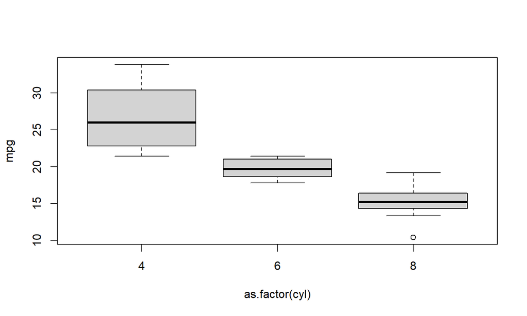

```r
plot(mpg ~ as.factor(cyl), data=mtcars)
```

## Pacotes R

## Instalar, carregar, atualizar, descarregar e desinstalar

Um pacote no R consiste numa coleção de funções, dados e código compilado - Existe um grande número de pacotes para R  
- Este pacotes estão alojados no [CRAN](https://www.r-project.org/) e podem ser instalados gratuitamente  
- Após download, os pacotes ficam guardados no nosso computador, numa pasta denominada de *library*.

```r
library() # lists installed packages
search() # lists loaded packages
packageVersion("psych") # check package version
citation("psych") # package citation
```

## Instalar pacotes

Existem várias formas de instalar pacotes no RStudio  
- Opção **point & click** no RStudio: **Tools > Install Packages…**  
- Código R, que pode ser gravado e executado sempre que iniciar sessão

```r
# Download package
install.packages("ggplot2")
?install.packages
# loading packages
library(Hmisc)

help(package="Hmisc")
```

## O pacote *“data.table”*

- Usado para trabalhar com dados em formato tabular
- Permite importar e manipular dados de forma muito eficiente
- Usa data.table em vez do formato data.frame (por defeito no R)

```r
install.packages("data.table")
help(package="data.table")
```

```r
library(data.table)
```

## O pacote *“data.table”*

A função fread() permite importar dados de forma rápida e fácil

```r
?data.table::fread
```

```r
bechdel <- fread("G:\\My Drive\\FPCEUP\\AtividadeDocente\\R_crash_course\\R crash course_Data\\bechdel.csv")
names(bechdel)
```

```
## [1] "movie_year"          "movie_title"         "bechdel_test"
## [4] "bechdel_test_binary" "budget"              "US_profit"
## [7] "Int_Profit"
```

```r
head(bechdel,3)
```

```
##    movie_year      movie_title bechdel_test bechdel_test_binary   budget
## 1:       2013        21 & Over            2                   0 13000000
## 2:       2012         Dredd 3D            5                   1 45658735
## 3:       2013 12 Years a Slave            2                   0 20000000
##    US_profit Int_Profit
## 1:  25682380   42195766
## 2:  13611086   41467257
## 3:  53107035  158607035
```

## O pacote *“psych”*

Incluí muitas funções úteis para análise de dados

```r
install.packages("psych")
help(package="psych")
```

```r
library(psych)
```

```r
class(bechdel)
```

```
## [1] "data.table" "data.frame"
```

```r
bechdel$movie_title <- as.character(bechdel$movie_title)
bechdel$bechdel_test_binary <- as.factor(bechdel$bechdel_test_binary)
sapply(bechdel, class)
```

```
##          movie_year         movie_title        bechdel_test bechdel_test_binary
##           "integer"         "character"           "integer"            "factor"
##              budget           US_profit          Int_Profit
##           "integer"           "integer"         "integer64"
```

## O pacote *“psych”*

```r
names(bechdel)
```

```
## [1] "movie_year"          "movie_title"         "bechdel_test"
## [4] "bechdel_test_binary" "budget"              "US_profit"
## [7] "Int_Profit"
```

```r
psych::describe(bechdel[ ,c(3,5)], range=FALSE)
```

```
##              vars    n        mean          sd  skew kurtosis         se
## bechdel_test    1 1788        3.53        1.48 -0.28    -1.56       0.03
## budget          2 1776 55619298.49 55010335.06  1.73     3.93 1305337.48
```

## O pacote *“psych”*

```r
describeBy(bechdel[ ,5], group=bechdel[ ,4], range=FALSE)
```

```
##
##  Descriptive statistics by group
## bechdel_test_binary: 0
##        vars   n     mean       sd skew kurtosis      se
## budget    1 978 63195031 58650759 1.51     3.15 1875444
## ------------------------------------------------------------
## bechdel_test_binary: 1
##        vars   n     mean       sd skew kurtosis      se
## budget    1 796 46146414 48371158 2.07     5.47 1714470
```

## O pacote *“psych”*

```r
reliab <- psych::alpha(bechdel[ ,c(5, 6)]) # Consistência interna
```

```
## Number of categories should be increased  in order to count frequencies.
```

```r
reliab$total
```

```
##  raw_alpha std.alpha   G6(smc) average_r      S/N        ase     mean       sd
##  0.5050602  0.630149 0.4600128 0.4600128 1.703791 0.01619229 74687215 79252832
##   median_r
##  0.4600128
```

## O pacote *“psych”*

```r
correlations <- corr.test(bechdel[ ,c(3, 5:7)])
correlations$r
```

```
##              bechdel_test     budget  US_profit  Int_Profit
## bechdel_test   1.00000000 -0.1525556 -0.1040053 -0.09277497
## budget        -0.15255562  1.0000000  0.4583005  0.59044129
## US_profit     -0.10400527  0.4583005  1.0000000  0.92745775
## Int_Profit    -0.09277497  0.5904413  0.9274577  1.00000000
```

```r
correlations$p
```

```
##              bechdel_test        budget    US_profit    Int_Profit
## bechdel_test 0.000000e+00  3.166474e-10 2.325606e-05  8.981476e-05
## budget       1.055491e-10  0.000000e+00 2.629266e-91 1.260639e-165
## US_profit    1.162803e-05  6.573165e-92 0.000000e+00  0.000000e+00
## Int_Profit   8.981476e-05 2.521278e-166 0.000000e+00  0.000000e+00
```

## O pacote *“psych”*

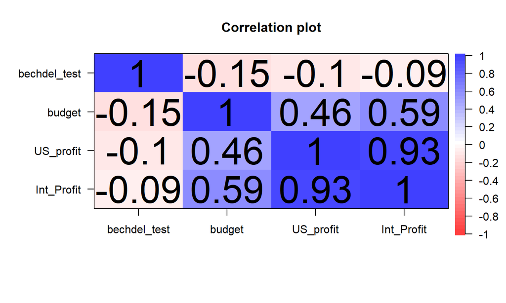

```r
cor.plot(bechdel[ ,c(3, 5:7)])
```

## Outros pacotes

- O pacote [ggplo2](https://cran.r-project.org/web/packages/ggplot2/index.html) para criar gráficos
- Os pacotes [mice](https://cran.r-project.org/web/packages/mice/index.html) e [amelia](https://cran.r-project.org/web/packages/Amelia/index.html) para análise e imputação de dados omissos
- Os pacotes [nlme](https://cran.r-project.org/web/packages/nlme/nlme.pdf) e [lme4](https://cran.r-project.org/web/packages/lme4/lme4.pdf) para modelos multinível
- Os pacotes [lavaan](https://cran.r-project.org/web/packages/lavaan/index.html) e [sem](https://cran.r-project.org/web/packages/sem/sem.pdf) para modelos de equações estruturais
- …